# Plotting means and error bars with significant difference

Fan Vincent Mo

11/12/2018

This is a brief introduction about how to plot means and error bars with significant difference, which is very commonly used in analysis of variance and multiple comparisons.

We will use the data of tapping error rate on the smartwatches’ screen, when the users in different moving speed. That is, people tap the smartwatch in standing, strolling, normal walking, rushing, and jogging.

### Needed libraries and functions

First, we need to include needed libraries, if you don’t have them in your computer, use `install.packages()` to install them.

```r
library(ggplot2)
library(plyr)
```

Second, we need to include the needed function for summarizing data. This is a function that you can find in [http://www.cookbook-r.com/]. Just run the code if you don’t want to look into it, just like me ;)

```r
## Gives count, mean, standard deviation, standard error of the mean, and confidence interval (default 95%).
##   data: a data frame.
##   measurevar: the name of a column that contains the variable to be summariezed
##   groupvars: a vector containing names of columns that contain grouping variables
##   na.rm: a boolean that indicates whether to ignore NA's
##   conf.interval: the percent range of the confidence interval (default is 95%)
summarySE <- function(data=NULL, measurevar, groupvars=NULL, na.rm=FALSE,
                      conf.interval=.95, .drop=TRUE) {
        library(plyr)

        # New version of length which can handle NA's: if na.rm==T, don't count them
        length2 <- function (x, na.rm=FALSE) {
                if (na.rm) sum(!is.na(x))
                else       length(x)
        }

        # This does the summary. For each group's data frame, return a vector with
        # N, mean, and sd
        datac <- ddply(data, groupvars, .drop=.drop,
                       .fun = function(xx, col) {
                               c(N    = length2(xx[[col]], na.rm=na.rm),
                                 mean = mean   (xx[[col]], na.rm=na.rm),
                                 sd   = sd     (xx[[col]], na.rm=na.rm)
                               )
                       },
                       measurevar
        )

        # Rename the "mean" column
        datac <- rename(datac, c("mean" = measurevar))

        datac$se <- datac$sd / sqrt(datac$N)  # Calculate standard error of the mean

        # Confidence interval multiplier for standard error
        # Calculate t-statistic for confidence interval:
        # e.g., if conf.interval is .95, use .975 (above/below), and use df=N-1
        ciMult <- qt(conf.interval/2 + .5, datac$N-1)
        datac$ci <- datac$se * ciMult

        return(datac)
}
```

### Prepare and clean the data

Then, we load the data. Look at the head of the data. *Subject* is the ID of the subject. *movement* consists of five movement conditions, which are sp1, sp2, sp3, sp4, and sp5. *errorrate* is the error rate of tapping.

```r
dat = read.csv("https://raw.githubusercontent.com/mofanv/datasharing/master/data_Marking_Significant_Difference.csv")
head(dat)
```

```
##   subject movement  errorrate
## 1       1      sp1 0.07969284
## 2       2      sp1 0.06659059
## 3       3      sp1 0.06181097
## 4       4      sp1 0.07772414
## 5       5      sp1 0.08632044
## 6       6      sp1 0.07722777
```

Now, we get the ANOVA results using `aov()` function. We can check the F value, p value by using `summary()` function.

```r
fit <- aov(errorrate ~ movement, dat)
summary(fit)
```

```
##              Df  Sum Sq   Mean Sq F value Pr(>F)
## movement      4 0.01180 0.0029490   30.58 <2e-16 ***
## Residuals   205 0.01977 0.0000964
## ---
## Signif. codes:  0 '***' 0.001 '**' 0.01 '*' 0.05 '.' 0.1 ' ' 1
```

We can also pick the F value and p value from the results, which could be useful in after analysis.

```r
#pick the F value, p value, and df
Fvalue <- round(summary(fit)[[1]][[4]][1],3)
Prvalue <- round(summary(fit)[[1]][[5]][1],3)
df <- paste0('(',summary(fit)[[1]][[1]][1], ',',summary(fit)[[1]][[1]][2],')')

#put a '*' if it is significant
if(as.numeric(Prvalue) <= 0.05) {markF = '*'}else{markF = ''}
Prvalue <- paste0(Prvalue, markF)

print(paste0('Fvalue is: ', Fvalue, '; Pvalue is: ', Prvalue, '; df values are: ',df))
```

```
## [1] "Fvalue is: 30.584; Pvalue is: 0*; df values are: (4,205)"
```

After getting the ANOVA results, we may want to look at the multiple comparison using TukeyHSD methods.

```r
# TukeyHSD
multComp <- TukeyHSD(fit)

#pick the p value
t_temp <- as.data.frame(multComp[[1]])
t_temp <- name_rows(t_temp)[,-c(1:3)]
t_temp
```

```
##           p adj .rownames
## 1  2.984505e-07   sp2-sp1
## 2  1.009710e-08   sp3-sp1
## 3  1.391764e-11   sp4-sp1
## 4  0.000000e+00   sp5-sp1
## 5  9.680322e-01   sp3-sp2
## 6  3.832321e-01   sp4-sp2
## 7  1.269263e-05   sp5-sp2
## 8  7.814274e-01   sp4-sp3
## 9  2.084694e-04   sp5-sp3
## 10 1.359571e-02   sp5-sp4
```

Now, this is a important step, using `summarySE()` function (we included it at the beginning) to summarize the data. Look at what we get now!

```r
#summary the data that will be used for ploting
resultsSE <- summarySE(data=dat, measurevar="errorrate", groupvars="movement")
resultsSE
```

```
##   movement  N  errorrate          sd          se          ci
## 1      sp1 42 0.07565979 0.009621002 0.001484553 0.002998115
## 2      sp2 42 0.08800878 0.008695865 0.001341801 0.002709822
## 3      sp3 42 0.08938351 0.010093953 0.001557531 0.003145497
## 4      sp4 42 0.09184057 0.011976252 0.001847976 0.003732063
## 5      sp5 42 0.09870029 0.008283137 0.001278116 0.002581207
```

In order to mark significant difference, first we need the text. We prepare the text based on the multiple comparison results **t_temp** which we already have.

```r
# prepare the text on the plot
signMark = c('','','','','')
for(i in 1:nrow(t_temp)){ # for each comparison
        #split the word using '-'
        word1 = strsplit(t_temp$.rownames[i],'-')[[1]][1]
        word2 = strsplit(t_temp$.rownames[i],'-')[[1]][2]
        #make the word with a index
        if(word1 == 'sp1'){loc1 = 1}
        if(word1 == 'sp2'){loc1 = 2}
        if(word1 == 'sp3'){loc1 = 3}
        if(word1 == 'sp4'){loc1 = 4}
        if(word1 == 'sp5'){loc1 = 5}
        if(word2 == 'sp1'){loc2 = 1}
        if(word2 == 'sp2'){loc2 = 2}
        if(word2 == 'sp3'){loc2 = 3}
        if(word2 == 'sp4'){loc2 = 4}
        if(word2 == 'sp5'){loc2 = 5}
        #if the p value is at significant level, put it into signMark vector
        if(0.01 <= t_temp$`p adj`[i] & t_temp$`p adj`[i] < 0.05){
                # () refers to 0.05 level
                signMark[loc1] = paste0(signMark[loc1],"(",as.character(loc2),")")
                signMark[loc2] = paste0(signMark[loc2],"(",as.character(loc1),")")
        }else if (0.001 <= t_temp$`p adj`[i] & t_temp$`p adj`[i]  < 0.01){
                # [] refers to 0.01 level
                signMark[loc1] = paste0(signMark[loc1],"[",as.character(loc2),"]")
                signMark[loc2] = paste0(signMark[loc2],"[",as.character(loc1),"]")
        }else if (t_temp$`p adj`[i] < 0.001){
                # {} refers to 0.001 level
                signMark[loc1] = paste0(signMark[loc1],"{",as.character(loc2),"}")
                signMark[loc2] = paste0(signMark[loc2],"{",as.character(loc1),"}")
        }
}
# look at the significant difference text
signMark
```

```
## [1] "{2}{3}{4}{5}" "{1}{5}"       "{1}{5}"       "{1}(5)"
## [5] "{1}{2}{3}(4)"
```

### Plot it

This is the final step, plot it using `ggplot()` function. If you are not fimilar with this function, I highly suggest you to have a look at this [http://www.cookbook-r.com/Graphs/]. It is very useful and powerful.

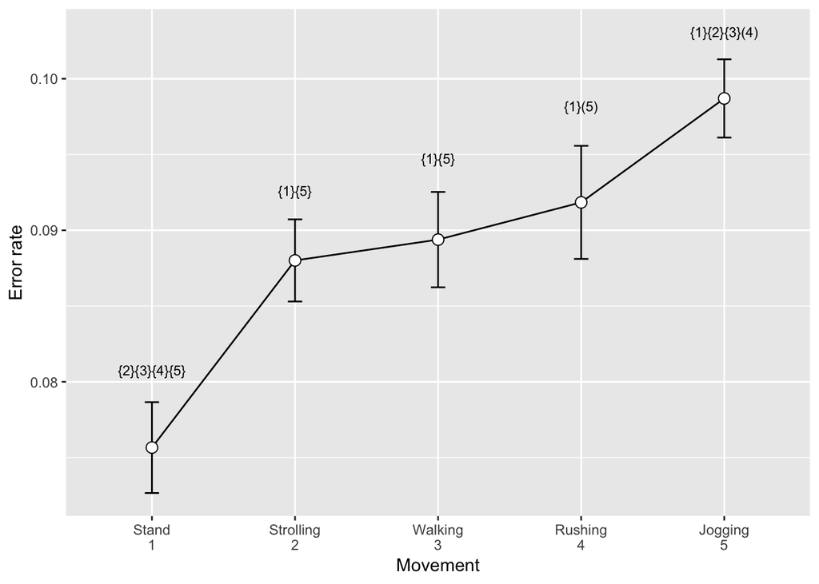

```r
# plot
p <- ggplot(resultsSE, aes(x = movement, y = errorrate)) +
        geom_line(group=1) +
        geom_errorbar(aes(ymin=errorrate-ci,ymax=errorrate+ci),width=0.1) +
        geom_point(size=3, shape=21, fill="white") +
        scale_x_discrete(name=paste0("Movement"),
                         limits=c('sp1','sp2','sp3','sp4','sp5'),
                         labels=c('sp1'='Stand\n1','sp2'='Strolling\n2','sp3'='Walking\n3',
                                  'sp4'='Rushing\n4','sp5'='Jogging\n5')) +
        scale_y_continuous(name = 'Error rate') +
        geom_text(aes(x = c(1,2,3,4,5), y = errorrate + 1.7 * ci, label = signMark), size = 3)
        # you probably need to change the parameters according to your data, when you use it.
p
```

### Congratulations! You made it!

### Try to use this in your papers, and you will win ;)